# Informe sobre ingreso en Estados Unidos

Fecha de publicación

14 de junio de 2026

## Instalación de librerías relevantes dentro de pacman

```r
# Instalo pacman si no está disponible para gestionar paquetes
if (!require("pacman")) install.packages("pacman")
# Cargo todas las librerías requeridas para la sesión
pacman::p_load(
  tidyverse,        # Manipulación de datos (dplyr, tidyr) y visualización (ggplot2)
  carData,          # Contiene el dataset 'Chile' que usaremos hoy
  caret,            # Herramientas para partición de datos (train/test split)
  scales,           # Formateo de ejes y etiquetas en gráficos (porcentajes, comas)
  broom,            # Convertir outputs de modelos en dataframes (tidy, glance, augment)
  modelsummary,     # Creación de tablas de regresión estilo publicación académica
  kableExtra,       # decoración de tablas kable
  marginaleffects,  # Cálculo de efectos marginales y predicciones
  yardstick,        # Métricas de evaluación de clasificación (ROC, AUC, Matriz de Confusión)
  patchwork,         # Organizar el apilado y composición de figuras
  janitor,
  here,
  stargazer
  )
```

## Cargo la base de datos y limpio los nombres

```r
censo <- read_csv(here("TP3", "data", "adult_census_USA.csv")) %>%
  clean_names()
```

## Transformación y selección de variables

Selecciono las variables demográficas y laborales pertinentes: educación, edad, clase de ocupación (workclass), raza y sexo. Convierto a la variable de ingreso (income) en un factor ordenado, donde <=50k es la base y >50k es el siguiente nivel.  
Luego, transformo las variables de educación, clase de ocupación, raza y sexo en variables discretas o binarias según corresponda para facilitar la interpretación. - Educación: discreta donde un valor más alto significa más educación - Clase de ocupación: dos variables binarias, una sobre si trabaja en el gobierno (cualquier tipo de gobierno) y otra sobre si no tiene sueldo (1 no tiene sueldo, 0 todo el resto de los tipos de trabajo). La categoría de referencia es ser trabajador privado o cuentapropista. - Raza: binaria donde 1 es ser “no blanco” (negro, asiático, etc) y 0 es ser blanco. - Sexo: binaria donde 1 es ser mujer y 0 es ser hombre. Además, creo la variable género para facilitar el armado de gráficos posteriormente. Posteriormente, veo si mi variable dependiente se encuentra balanceada. A la hora de hacer una estimación logística es importante verificar que la variable objetivo se encuentre balanceada. En este caso, la distribución de `income` muestra que hay una cantidad relativamente similar de observaciones para ingresos bajos (`<=50K`) e ingresos altos (`>50K`).Esto indica que el dataset está bastante balanceado, por lo que no parece necesario aplicar técnicas adicionales como submuestreo, sobremuestreo o ajustes ponderados. Este balance permite enfocarnos en la interpretación del modelo.

```r
censo <- censo %>% select(education, age, workclass, race, sex, income)

censo <- censo %>% mutate(
  income = factor(
      income,
      levels = c("<=50K", ">50K")),
  education = case_when(
      education == "Preschool"   ~ 1,
      education == "1st-4th"     ~ 2,
      education == "5th-6th"     ~ 3,
      education == "7th-8th"     ~ 4,
      education == "9th"         ~ 5,
      education == "10th"        ~ 6,
      education == "11th"        ~ 7,
      education == "12th"        ~ 8,
      education == "HS-grad"     ~ 9,
      education == "Some-college"~ 10,
      education == "Assoc-voc"   ~ 11,
      education == "Assoc-acdm"  ~ 12,
      education == "Bachelors"   ~ 13,
      education == "Masters"     ~ 14,
      education == "Prof-school" ~ 15,
      education == "Doctorate"   ~ 16,
      TRUE ~ NA_real_
    ),
  no_blanco = case_when(
    race == "Black" ~ 1,
    race == "Asian-Pac-Islander" ~ 1,
    race == "Amer-Indian-Eskimo" ~ 1,
    race == "Other" ~ 1,
    race == "White" ~ 0,
    TRUE ~ NA_real_),
  trabaja_gob = case_when(
    workclass == "State-gov" ~ 1,
    workclass == "Federal-gov" ~ 1,
    workclass == "Local-gov" ~ 1,
    workclass == "Self-emp-not-inc" ~ 0,
    workclass == "Self-emp-inc" ~ 0,
    workclass == "Without-pay" ~ 0,
    workclass == "Private" ~ 0,
    TRUE ~ NA_real_),
  sin_sueldo = case_when(
    workclass == "State-gov" ~ 0,
    workclass == "Federal-gov" ~ 0,
    workclass == "Local-gov" ~ 0,
    workclass == "Self-emp-not-inc" ~ 0,
    workclass == "Self-emp-inc" ~ 0,
    workclass == "Without-pay" ~ 1,
    workclass == "Private" ~ 0,
    TRUE ~ NA_real_),
  sexo = ifelse(sex == "Female", 1, 0),
  genero = ifelse(sex == "Female", "Mujeres", "Hombres")
  )

# Comprobamos el balance de nuestra variable objetivo
message("Distribución de la variable objetivo (income):")
```

```
Distribución de la variable objetivo (income):
```

```r
print(table(censo$income))
```

```
<=50K  >50K
 8258  7508
```

```r
message("Proporciones:")
```

```
Proporciones:
```

```r
print(prop.table(table(censo$income)) |> round(3))
```

```
<=50K  >50K
0.524 0.476
```

La variable dependiente está razonablemente balanceada, 52% <=50K y 47% >50K.

## Análisis Exploratorio y Decisiones de Transformación

Primero, realizo visualizaciones bivariadas entre potenciales variables explicativas y la variable dependiente, ingreso.

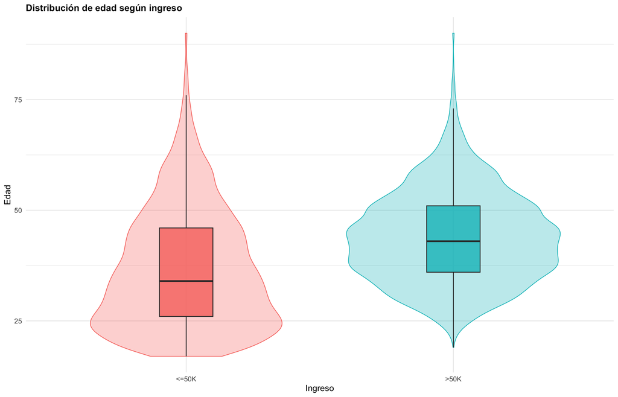

```r
edad_ingreso <- censo %>%
  ggplot(aes(x = income, y = age, fill = income, color = income)) +
  geom_violin(alpha = 0.3, linewidth = 0.5, width = 0.8) +
  geom_boxplot(width = 0.2, alpha = 0.8, color = "gray20", outlier.shape = NA) +
  labs(
    title = "Distribución de edad según ingreso",
    x = "Ingreso",
    y = "Edad"
  ) +
  theme_minimal(base_size = 14) +
  theme(
    plot.title = element_text(face = "bold", size = 15),
    legend.position = "none"
  )

print(edad_ingreso)
```

Edad e ingreso: los individuos con ingresos superiores a USD 50.000 presentan una distribución desplazada hacia edades más altas y una mediana superior a la observada en el grupo de menores ingresos. Esto sugiere que la edad podría estar positivamente asociada con la probabilidad de pertenecer al grupo de ingresos altos, posiblemente debido a una mayor experiencia laboral acumulada.

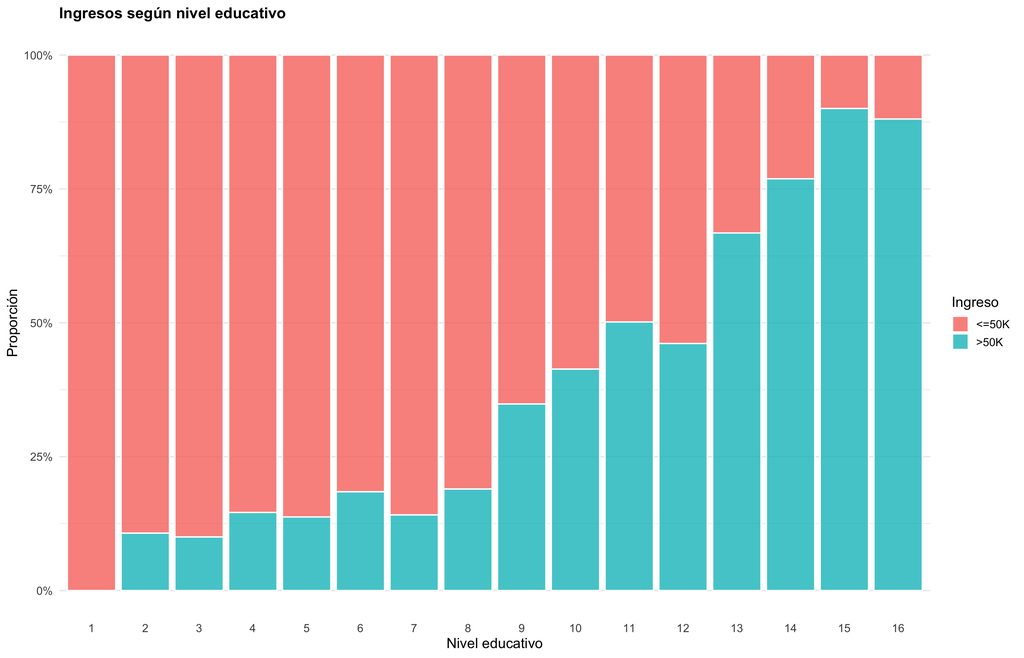

```r
educacion_ingreso <- censo %>%
  ggplot(aes(x = factor(education), fill = income)) +
  geom_bar(position = "fill", alpha = 0.8, color = "white") +
  scale_y_continuous(labels = scales::percent) +
  labs(
    title = "Ingresos según nivel educativo",
    x = "Nivel educativo",
    y = "Proporción",
    fill = "Ingreso"
  ) +
  theme_minimal(base_size = 14) +
  theme(
    plot.title = element_text(face = "bold", size = 15),
    panel.grid.major.x = element_blank()
  )

print(educacion_ingreso)
```

Educación e ingreso: a medida que aumenta el nivel educativo, crece sistemáticamente la proporción de individuos con ingresos superiores a USD 50.000.

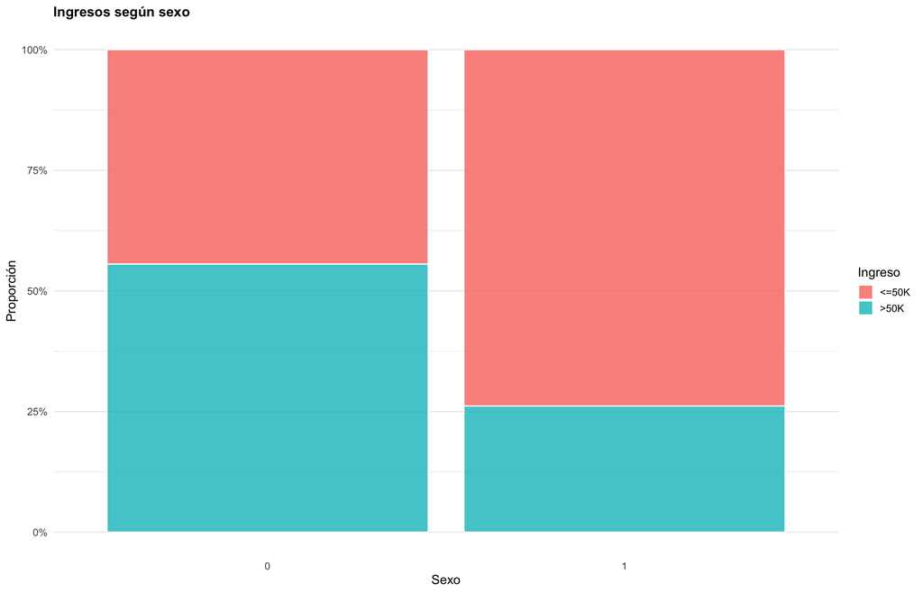

```r
sexo_ingreso <- censo %>%
  ggplot(aes(x = factor(sexo), fill = income)) +
  geom_bar(position = "fill", alpha = 0.8, color = "white") +
  scale_y_continuous(labels = scales::percent) +
  labs(
    title = "Ingresos según sexo",
    x = "Sexo",
    y = "Proporción",
    fill = "Ingreso"
  ) +
  theme_minimal(base_size = 14) +
  theme(
    plot.title = element_text(face = "bold", size = 15),
    panel.grid.major.x = element_blank()
  )

print(sexo_ingreso)
```

Sexo e ingreso: en mujeres es más común ver una mayor concentración de personas con ingresos iguales o por debajo a 50K. En hombres, la distribución es equitativa.

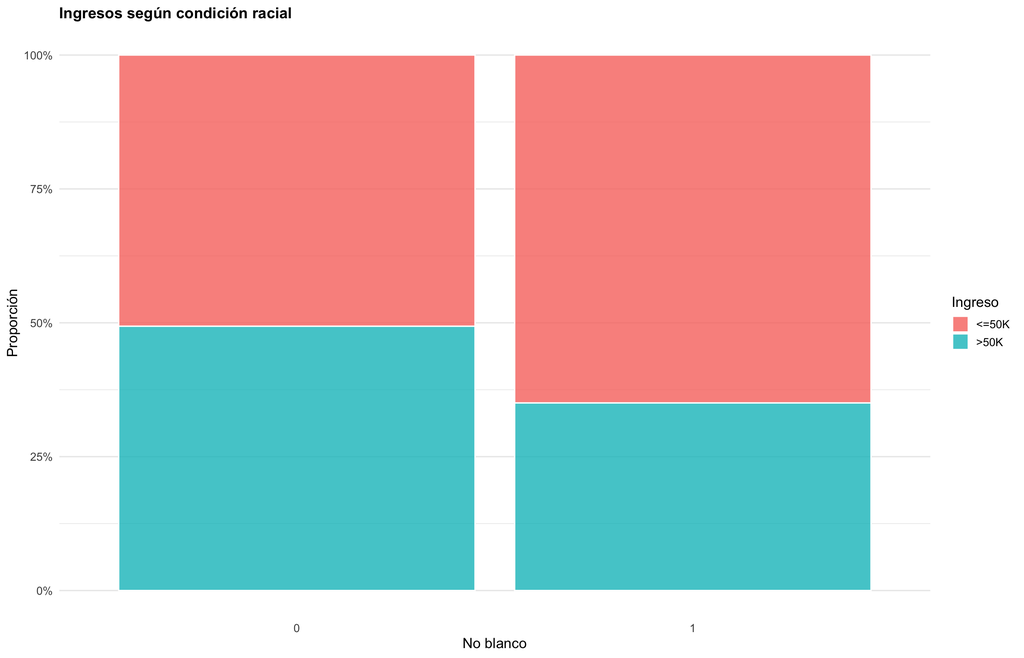

```r
no_blanco_ingreso <- censo %>%
  ggplot(aes(x = factor(no_blanco), fill = income)) +
  geom_bar(position = "fill", alpha = 0.8, color = "white") +
  scale_y_continuous(labels = scales::percent) +
  labs(
    title = "Ingresos según condición racial",
    x = "No blanco",
    y = "Proporción",
    fill = "Ingreso"
  ) +
  theme_minimal(base_size = 14) +
  theme(
    plot.title = element_text(face = "bold", size = 15),
    panel.grid.major.x = element_blank()
  )

print(no_blanco_ingreso)
```

No blanco e ingreso: los individuos clasificados como blancos (0) presentan una proporción mayor de ingresos altos que aquellos clasificados como no blancos (1).

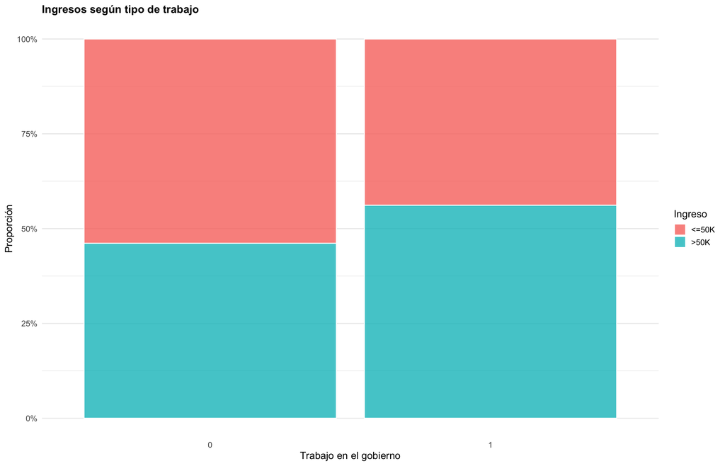

```r
tipo_trabajo_ingreso <- censo %>%
  ggplot(aes(x = factor(trabaja_gob), fill = income)) +
  geom_bar(position = "fill", alpha = 0.8, color = "white") +
  scale_y_continuous(labels = scales::percent) +
  labs(
    title = "Ingresos según tipo de trabajo",
    x = "Trabajo en el gobierno",
    y = "Proporción",
    fill = "Ingreso"
  ) +
  theme_minimal(base_size = 14) +
  theme(
    plot.title = element_text(face = "bold", size = 15),
    panel.grid.major.x = element_blank()
  )

print(tipo_trabajo_ingreso)
```

Tipo de trabajo (trabajo en el gobierno) e ingreso: los individuos que no pertenecen al grupo de trabajadores en el gobierno (0) muestran una proporción ligeramente inferior de ingresos altos respecto de aquellos clasificados como trabajadores gubernamentales (1). De todas formas, no se ve un efecto tan significativo.

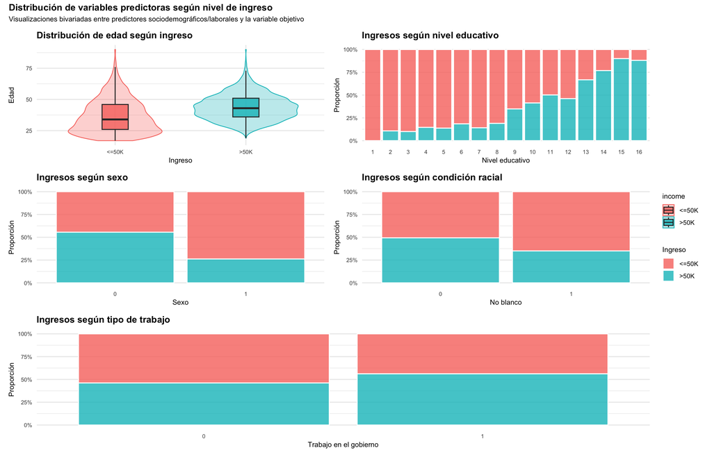

```r
# Combino los gráficos
grafico_combinado <- (
  (edad_ingreso | educacion_ingreso) /
  (sexo_ingreso | no_blanco_ingreso) /
  tipo_trabajo_ingreso
) +
  plot_layout(guides = "collect", heights = c(1, 1, 1)) +
  plot_annotation(
    title = "Distribución de variables predictoras según nivel de ingreso",
    subtitle = "Visualizaciones bivariadas entre predictores sociodemográficos/laborales y la variable objetivo"
  ) &
  theme(
    legend.position = "right",
    plot.title = element_text(face = "bold", size = 13),
    plot.subtitle = element_text(size = 10),
    axis.title = element_text(size = 10),
    axis.text = element_text(size = 8),
    legend.title = element_text(size = 10),
    legend.text = element_text(size = 9)
  )

print(grafico_combinado)
```

A partir de la exploración visual no se observan distribuciones extremadamente asimétricas ni valores atípicos que justifiquen aplicar transformaciones adicionales sobre la variable edad. Por lo tanto, se mantendrá en su escala original.

Asimismo, los gráficos sugieren una posible interacción entre educación y sexo. Teóricamente, el retorno económico de la educación podría diferir entre hombres y mujeres debido a diferencias persistentes en el mercado laboral y esto se comprueba por la asimetría vista en los gráficos que sugiere la posibilidad de una interacción. Para comprobarlo, realizo un gráfico bivariado entre educación e ingreso faceteado por género para asegurarme de que la distribución es diferente en base al género.

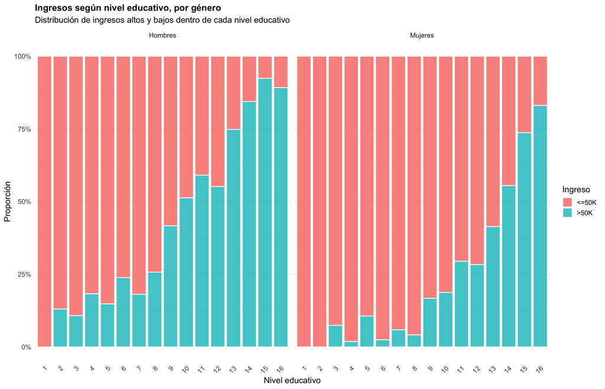

```r
educacion_ingreso_genero <- censo %>%
  ggplot(aes(x = factor(education), fill = income)) +
  geom_bar(position = "fill", alpha = 0.8, color = "white") +
  facet_wrap(~ genero) +
  scale_y_continuous(labels = scales::percent) +
  labs(
    title = "Ingresos según nivel educativo, por género",
    subtitle = "Distribución de ingresos altos y bajos dentro de cada nivel educativo",
    x = "Nivel educativo",
    y = "Proporción",
    fill = "Ingreso"
  ) +
  theme_minimal(base_size = 14) +
  theme(
    plot.title = element_text(face = "bold", size = 15),
    panel.grid.major.x = element_blank(),
    axis.text.x = element_text(angle = 45, hjust = 1)
  )

print(educacion_ingreso_genero)
```

El gráfico permite observar la relación entre nivel educativo e ingreso separadamente para hombres y mujeres. En ambos grupos, la proporción de personas con ingresos superiores a USD 50.000 aumenta a medida que crece el nivel educativo. Sin embargo, la distribución no parece idéntica entre géneros: para niveles educativos similares, las mujeres presentan una menor proporción de ingresos altos que los hombres.

Esto no prueba por sí solo que exista una interacción estadísticamente significativa, pero sí justifica incluirla en el modelo. Visualmente, resulta razonable evaluar si el efecto de la educación sobre la probabilidad de obtener ingresos altos varía según el género.

## Ajuste de Modelos (Regresión Logística)

Realizo dos modelos: uno con las variables explicativas de forma directa y uno que incluye las variables interactuadas. La categoría de referencia para income es <=50K. Para sexo, la referencia es hombre (0). Para raza, blanco (0). Para tipo de trabajo, trabajadores privados o cuentapropistas. 1. Modelo 1: ingreso como variable dependiente. Sexo (ser mujer), raza (no ser blanco), tipo de trabajo (ser trabajador de gobierno o no tener sueldo (con ser un trabajador privado/cuentapropista como variable de referencia), edad, educación (más alto es mayor nivel educativo). 2. Modelo 2: mismas variables dependientes y explicativas, con la adición de una variable explicativa interactuada entre sexo (ser mujer) y nivel educativo.

```r
modelo_logit1 <- glm(
  income ~
    sexo +
    age +
    no_blanco +
    education +
    trabaja_gob +
    sin_sueldo,
  data = censo,
  family = binomial(link = "logit")
)

modelo_logit2 <- glm(
  income ~
    sexo +
    age +
    no_blanco +
    education +
    trabaja_gob +
    sin_sueldo +
    sexo*education,
  data = censo,
  family = binomial(link = "logit")
)

summary(modelo_logit1)
```

```
Call:
glm(formula = income ~ sexo + age + no_blanco + education + trabaja_gob +
    sin_sueldo, family = binomial(link = "logit"), data = censo)

Coefficients:
              Estimate Std. Error z value Pr(>|z|)
(Intercept)  -5.656896   0.118753 -47.636  < 2e-16 ***
sexo         -1.322836   0.044870 -29.481  < 2e-16 ***
age           0.050374   0.001607  31.348  < 2e-16 ***
no_blanco    -0.342842   0.059367  -5.775  7.7e-09 ***
education     0.367053   0.008551  42.926  < 2e-16 ***
trabaja_gob   0.061990   0.052888   1.172    0.241
sin_sueldo  -11.421943  89.115327  -0.128    0.898
---
Signif. codes:  0 '***' 0.001 '**' 0.01 '*' 0.05 '.' 0.1 ' ' 1

(Dispersion parameter for binomial family taken to be 1)

    Null deviance: 21821  on 15765  degrees of freedom
Residual deviance: 17042  on 15759  degrees of freedom
AIC: 17056

Number of Fisher Scoring iterations: 10
```

```r
summary(modelo_logit2)
```

```
Call:
glm(formula = income ~ sexo + age + no_blanco + education + trabaja_gob +
    sin_sueldo + sexo * education, family = binomial(link = "logit"),
    data = censo)

Coefficients:
                 Estimate Std. Error z value Pr(>|z|)
(Intercept)     -5.609727   0.126122 -44.479  < 2e-16 ***
sexo            -1.568616   0.230795  -6.797 1.07e-11 ***
age              0.050437   0.001609  31.346  < 2e-16 ***
no_blanco       -0.341523   0.059394  -5.750 8.92e-09 ***
education        0.362317   0.009558  37.907  < 2e-16 ***
trabaja_gob      0.058760   0.052971   1.109    0.267
sin_sueldo     -11.421317  89.195390  -0.128    0.898
sexo:education   0.022289   0.020505   1.087    0.277
---
Signif. codes:  0 '***' 0.001 '**' 0.01 '*' 0.05 '.' 0.1 ' ' 1

(Dispersion parameter for binomial family taken to be 1)

    Null deviance: 21821  on 15765  degrees of freedom
Residual deviance: 17041  on 15758  degrees of freedom
AIC: 17057

Number of Fisher Scoring iterations: 10
```

La tabla presenta los resultados de los dos modelos logísticos estimados. El Modelo 1 incluye únicamente los efectos principales de las variables seleccionadas, mientras que el Modelo 2 incorpora además una interacción entre sexo y educación.

Los resultados muestran que las variables más relevantes para explicar la probabilidad de obtener ingresos superiores a USD 50.000 son la educación, la edad, el sexo y la condición racial. En ambos modelos, la educación presenta un efecto positivo y estadísticamente significativo, indicando que mayores niveles educativos aumentan la probabilidad de pertenecer al grupo de ingresos altos. Asimismo, la edad tiene un efecto positivo y significativo, mientras que ser mujer y no ser blanco se asocian con una menor probabilidad de alcanzar ingresos elevados.

Por el contrario, la variable trabajo en el gobierno no resulta estadísticamente significativa en ninguno de los modelos, por lo que no existe evidencia suficiente para afirmar que trabajar en el sector público modifique la probabilidad de obtener ingresos superiores a USD 50.000. De manera similar, la categoría sin sueldo presenta coeficientes extremadamente inestables y errores estándar muy elevados, lo que sugiere una escasa cantidad de observaciones en dicha categoría y dificulta una interpretación sustantiva confiable.

Respecto de la interacción incorporada en el Modelo 2, el coeficiente asociado a Sexo × Educación es positivo (0.022), pero no resulta estadísticamente significativo. Esto indica que no existe evidencia suficiente para sostener que el efecto de la educación sobre los ingresos sea diferente para hombres y mujeres. En otras palabras, aunque la educación aumenta la probabilidad de obtener ingresos altos, dicho efecto parece ser similar para ambos sexos.

Al comparar el Modelo 1 y el Modelo 2, los coeficientes principales mantienen signo, magnitud e inferencia estadística similares. La incorporación de la interacción sexo × educación no mejora sustancialmente la explicación del fenómeno y además el término interactivo no resulta significativo.

## Interpretación de Resultados y Efectos Marginales

```r
# Efectos Marginales Promedio (AME)
efectos_marginales <- avg_slopes(
  modelo_logit2
)

efectos_marginales %>%
  select(term, contrast, estimate, conf.low, conf.high, p.value) %>%
  mutate(
    estimate_pct = paste0(round(estimate * 100, 2), "%"),
    interpretacion = case_when(
      estimate > 0 & p.value < 0.05 ~ "Aumenta prob. (Sig.)",
      estimate < 0 & p.value < 0.05 ~ "Reduce prob. (Sig.)",
      TRUE ~ "No significativo"
    )
  ) %>%
  select(
    term,
    contrast,
    estimate_pct,
    conf.low,
    conf.high,
    p.value,
    interpretacion
  ) %>%
  rename(
    Predictor = term,
    Contraste = contrast,
    `Efecto (Prob)` = estimate_pct,
    `IC Inferior` = conf.low,
    `IC Superior` = conf.high,
    `Valor p` = p.value,
    Interpretación = interpretacion
  ) %>%
  knitr::kable(
    digits = 4,
    caption = "Efectos Marginales Promedio (AME)"
  ) %>%
  kableExtra::kable_styling(
    bootstrap_options = c(
      "striped",
      "hover",
      "condensed",
      "responsive"
    ),
    full_width = FALSE,
    position = "center"
  ) %>%
  kableExtra::row_spec(
    row = which(efectos_marginales$p.value < 0.05),
    bold = TRUE,
    background = "#e6f2ff"
  )
```

Efectos Marginales Promedio (AME)

| Predictor | Contraste | Efecto (Prob) | IC Inferior | IC Superior | Valor p | Interpretación |
| --- | --- | --- | --- | --- | --- | --- |
| age | dY/dX | 0.92% | 0.0087 | 0.0097 | 0.0000 | Aumenta prob. (Sig.) |
| education | dY/dX | 6.68% | 0.0645 | 0.0692 | 0.0000 | Aumenta prob. (Sig.) |
| no_blanco | 1 - 0 | -6.21% | -0.0832 | -0.0411 | 0.0000 | Reduce prob. (Sig.) |
| sexo | 1 - 0 | -24.51% | -0.2601 | -0.2300 | 0.0000 | Reduce prob. (Sig.) |
| sin_sueldo | 1 - 0 | -47.63% | -0.4841 | -0.4685 | 0.0000 | Reduce prob. (Sig.) |
| trabaja_gob | 1 - 0 | 1.07% | -0.0082 | 0.0296 | 0.2678 | No significativo |

Nota sobre la interacción: aunque el Modelo 2 incluye una interacción entre sexo y educación, esta no aparece como una fila independiente en la tabla de Efectos Marginales Promedio (AME). Esto ocurre porque los AME reportan los efectos marginales de cada predictor sobre la probabilidad predicha, incorporando automáticamente el efecto de la interacción en dichos cálculos. Por este motivo, la interacción debe interpretarse a partir de los coeficientes del modelo logístico y no como un efecto marginal separado.

- **Edad (dY/dX):** en promedio, un año adicional de edad aumenta la probabilidad de obtener ingresos superiores a USD 50.000 en aproximadamente 0.92 puntos porcentuales.
- **Educación (dY/dX):** en promedio, un año adicional de educación aumenta la probabilidad de pertenecer al grupo de ingresos altos en aproximadamente 6.68 puntos porcentuales. Se trata del predictor continuo con mayor efecto positivo.
- **No blanco (1-0):** en promedio, las personas no blancas presentan una probabilidad 6.21 puntos porcentuales menor de pertenecer al grupo de ingresos altos.
- **Sexo (Mujer-Hombre):** en promedio, las mujeres presentan una probabilidad 24.51 puntos porcentuales menor de obtener ingresos superiores a USD 50.000 respecto de los hombres.
- **Sin sueldo (1-0):** las personas clasificadas como sin sueldo presentan una probabilidad significativamente menor de pertenecer al grupo de ingresos altos.
- **Trabajo en el gobierno (1-0):** el efecto estimado es positivo, pero no resulta estadísticamente significativo.

Se incorporó una interacción entre sexo y educación con el objetivo de evaluar si el efecto de la educación sobre los ingresos difiere entre hombres y mujeres. Sin embargo, el coeficiente asociado a la interacción no resulta estadísticamente significativo, por lo que no existe evidencia suficiente para afirmar que los retornos de la educación sean distintos según el sexo. En consecuencia, el efecto positivo de la educación sobre la probabilidad de obtener ingresos altos parece ser similar para hombres y mujeres.

```
`height` was translated to `width`.
`height` was translated to `width`.
`height` was translated to `width`.
```

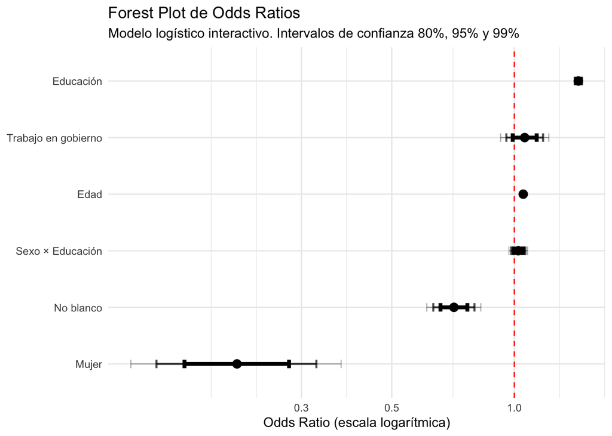

```r
or_99 <- broom::tidy(modelo_logit2, exponentiate = TRUE,
                     conf.int = TRUE, conf.level = 0.99)
or_95 <- broom::tidy(modelo_logit2, exponentiate = TRUE,
                     conf.int = TRUE, conf.level = 0.95)
or_80 <- broom::tidy(modelo_logit2, exponentiate = TRUE,
                     conf.int = TRUE, conf.level = 0.80)
forest_data <- or_99 %>%
  select(term, estimate, p.value, low99 = conf.low, high99 = conf.high) %>%
  left_join(
    or_95 %>% select(term, low95 = conf.low, high95 = conf.high),
    by = "term"
  ) %>%
  left_join(
    or_80 %>% select(term, low80 = conf.low, high80 = conf.high),
    by = "term"
  ) %>%
  filter(
    term != "(Intercept)",
    term != "sin_sueldo"   # se excluye solo del gráfico porque distorsiona la escala
  ) %>%
  mutate(
    term = recode(
      term,
      "age" = "Edad",
      "education" = "Educación",
      "sexo" = "Mujer",
      "no_blanco" = "No blanco",
      "trabaja_gob" = "Trabajo en gobierno",
      "sexo:education" = "Sexo × Educación"
    )
  )

forest_plot <- ggplot(forest_data,
       aes(y = reorder(term, estimate),
           x = estimate)) +
  geom_vline(
    xintercept = 1,
    linetype = "dashed",
    color = "red"
  ) +
  geom_errorbarh(
    aes(xmin = low99, xmax = high99),
    height = 0.15,
    linewidth = 0.4,
    alpha = 0.35
  ) +
  geom_errorbarh(
    aes(xmin = low95, xmax = high95),
    height = 0.15,
    linewidth = 0.8,
    alpha = 0.7
  ) +
  geom_errorbarh(
    aes(xmin = low80, xmax = high80),
    height = 0.15,
    linewidth = 1.5
  ) +
  geom_point(size = 3) +
  scale_x_log10() +
  labs(
    title = "Forest Plot de Odds Ratios",
    subtitle = "Modelo logístico interactivo. Intervalos de confianza 80%, 95% y 99%",
    x = "Odds Ratio (escala logarítmica)",
    y = NULL
  ) +
  theme_minimal()
print(forest_plot)
```

```r
ggsave(
  filename = here("TP3", "Gráficos forest.png"),
  plot = forest_plot,
  width = 16,
  height = 10,
  dpi = 300
)
```

```
`height` was translated to `width`.
`height` was translated to `width`.
`height` was translated to `width`.
```

Para facilitar la interpretación de los coeficientes del modelo logístico, se transformaron los coeficientes estimados en Odds Ratios (OR) mediante la función exponencial. Los Odds Ratios indican cuánto se multiplican las chances (odds) de obtener ingresos superiores a USD 50.000 ante un cambio unitario en una variable explicativa, manteniendo constantes las demás variables.

Si OR > 1, la variable aumenta las chances de pertenecer al grupo de ingresos altos. Si OR < 1, la variable disminuye las chances. Si OR = 1, la variable no tiene efecto sobre las chances.

A continuación se presenta un forest plot con los Odds Ratios estimados para el Modelo 2. El gráfico utiliza escala logarítmica en el eje horizontal e incluye intervalos de confianza del 80%, 95% y 99%, tal como solicita la consigna. La línea vertical roja indica el valor OR = 1, que representa ausencia de efecto.

La variable sin_sueldo fue excluida únicamente de la visualización del forest plot. Esta variable permanece dentro del modelo y en las tablas de resultados. Sin embargo, presenta un Odds Ratio extremadamente pequeño acompañado de intervalos de confianza muy amplios, producto de la escasa cantidad de observaciones en esa categoría. Su inclusión en el gráfico distorsiona la escala logarítmica y dificulta la visualización del resto de los coeficientes. Por este motivo se la omite únicamente con fines gráficos, sin alterar la estimación del modelo.

Los resultados del Forest Plot muestran: - Educación presenta un Odds Ratio superior a 1 y claramente significativo. Esto indica que mayores niveles educativos aumentan las chances de pertenecer al grupo de ingresos superiores a USD 50.000. - Mujer presenta un Odds Ratio inferior a 1, lo que implica menores chances de pertenecer al grupo de ingresos altos respecto de los hombres. - No blanco también presenta un Odds Ratio inferior a 1, indicando menores chances de obtener ingresos altos en comparación con las personas blancas. - Edad presenta un efecto positivo pero relativamente pequeño. - Trabajo en gobierno presenta un Odds Ratio cercano a 1 y su intervalo de confianza incluye el valor de referencia, por lo que no existe evidencia estadística suficiente para afirmar que trabajar en el gobierno modifica las chances de obtener ingresos altos. - La interacción Sexo × Educación presenta un Odds Ratio muy cercano a 1 y sus intervalos de confianza atraviesan el valor de referencia. Esto coincide con los resultados del modelo logístico, donde el coeficiente de interacción no resultó estadísticamente significativo. Por lo tanto, no existe evidencia suficiente para afirmar que el efecto de la educación sobre los ingresos sea distinto para hombres y mujeres.

## Comparación global de los modelos

Para evaluar el desempeño global de los modelos se compararon el AIC, la deviance y el Pseudo-R². El Modelo 2 presenta una deviance levemente menor (17041 frente a 17042), lo que indica una mejora marginal en el ajuste. Sin embargo, el AIC aumenta ligeramente (17056.57 frente a 17055.76), mientras que el Pseudo-R² permanece prácticamente idéntico en ambos modelos (0.219).

Si bien la incorporación de la interacción entre sexo y educación produce una mejora mínima en el ajuste del modelo, dicha mejora es prácticamente nula desde el punto de vista sustantivo. El término interactivo no resulta estadísticamente significativo, el Pseudo-R² no aumenta y el AIC incluso empeora ligeramente. Por lo tanto, no existe evidencia suficiente para concluir que la inclusión de la interacción mejore el modelo de manera relevante. En consecuencia, el Modelo 1 resulta preferible por su mayor simplicidad, ya que alcanza prácticamente el mismo poder explicativo utilizando una especificación más simple.

```r
glance_m1 <- broom::glance(modelo_logit1)
glance_m2 <- broom::glance(modelo_logit2)

pseudo_r2_m1 <- 1 - (modelo_logit1$deviance /
                     modelo_logit1$null.deviance)

pseudo_r2_m2 <- 1 - (modelo_logit2$deviance /
                     modelo_logit2$null.deviance)

comparacion_modelos <- tibble(
  Modelo = c("Modelo 1", "Modelo 2"),
  AIC = c(
    glance_m1$AIC,
    glance_m2$AIC
  ),
  Pseudo_R2 = c(
    pseudo_r2_m1,
    pseudo_r2_m2
  ),
  Deviance = c(
    glance_m1$deviance,
    glance_m2$deviance
  )
)

print(comparacion_modelos)
```

```
# A tibble: 2 × 4
  Modelo      AIC Pseudo_R2 Deviance
  <chr>     <dbl>     <dbl>    <dbl>
1 Modelo 1 17056.     0.219   17042.
2 Modelo 2 17057.     0.219   17041.
```

## Conclusión general

Los resultados obtenidos indican que la educación es el factor más importante para explicar la probabilidad de obtener ingresos superiores a USD 50.000 en Estados Unidos. A medida que aumenta el nivel educativo, aumentan significativamente las chances de pertenecer al grupo de mayores ingresos. Asimismo, la edad presenta un efecto positivo, lo que sugiere que la experiencia acumulada en el mercado laboral también contribuye a alcanzar niveles salariales más elevados.

Por otro lado, ser mujer y no ser blanco se asocian con una menor probabilidad de obtener ingresos altos, incluso controlando por las demás variables incluidas en el modelo. En cambio, no se encontró evidencia estadísticamente significativa de que trabajar en el gobierno modifique la probabilidad de pertenecer al grupo de ingresos superiores a USD 50.000.

Finalmente, se evaluó una especificación alternativa incorporando una interacción entre sexo y educación para analizar si los retornos de la educación difieren entre hombres y mujeres. Sin embargo, el término interactivo no resultó estadísticamente significativo y las medidas de ajuste mostraron cambios prácticamente nulos. Por lo tanto, no existe evidencia suficiente para afirmar que la inclusión de la interacción mejore el modelo, por lo que el Modelo 1 resulta preferible por ser más simple y ofrecer prácticamente el mismo poder explicativo que el Modelo 2.